# Red Wine Analysis by Harsh Masher

# About

This data set contains 1,599 red wines with 11 variables on the chemical properties of the wine. The quality of each wine was rated between 0 (very bad) and 10 (very excellent) by atleast three wine experts. I will be using the statistical program R to evaluate the dataset with descriptive statistics and exploratory data analysis.

# Univariate Plots Section

In this section, I will perform some preliminary exploratory analysis of the dataset. I will run some basic functions and create univaraite plots to understand the structure of the dataset and individual variables.

To start the analysis, it is important to understand the basic structure of the dataset. Below, the interquartile range, minimum, maximum, median, and mean values of the individual values are listed.

```
##        X          fixed.acidity   volatile.acidity  citric.acid
##  Min.   :   1.0   Min.   : 4.60   Min.   :0.1200   Min.   :0.000
##  1st Qu.: 400.5   1st Qu.: 7.10   1st Qu.:0.3900   1st Qu.:0.090
##  Median : 800.0   Median : 7.90   Median :0.5200   Median :0.260
##  Mean   : 800.0   Mean   : 8.32   Mean   :0.5278   Mean   :0.271
##  3rd Qu.:1199.5   3rd Qu.: 9.20   3rd Qu.:0.6400   3rd Qu.:0.420
##  Max.   :1599.0   Max.   :15.90   Max.   :1.5800   Max.   :1.000
##  residual.sugar     chlorides       free.sulfur.dioxide
##  Min.   : 0.900   Min.   :0.01200   Min.   : 1.00
##  1st Qu.: 1.900   1st Qu.:0.07000   1st Qu.: 7.00
##  Median : 2.200   Median :0.07900   Median :14.00
##  Mean   : 2.539   Mean   :0.08747   Mean   :15.87
##  3rd Qu.: 2.600   3rd Qu.:0.09000   3rd Qu.:21.00
##  Max.   :15.500   Max.   :0.61100   Max.   :72.00
##  total.sulfur.dioxide    density             pH          sulphates
##  Min.   :  6.00       Min.   :0.9901   Min.   :2.740   Min.   :0.3300
##  1st Qu.: 22.00       1st Qu.:0.9956   1st Qu.:3.210   1st Qu.:0.5500
##  Median : 38.00       Median :0.9968   Median :3.310   Median :0.6200
##  Mean   : 46.47       Mean   :0.9967   Mean   :3.311   Mean   :0.6581
##  3rd Qu.: 62.00       3rd Qu.:0.9978   3rd Qu.:3.400   3rd Qu.:0.7300
##  Max.   :289.00       Max.   :1.0037   Max.   :4.010   Max.   :2.0000
##     alcohol         quality
##  Min.   : 8.40   Min.   :3.000
##  1st Qu.: 9.50   1st Qu.:5.000
##  Median :10.20   Median :6.000
##  Mean   :10.42   Mean   :5.636
##  3rd Qu.:11.10   3rd Qu.:6.000
##  Max.   :14.90   Max.   :8.000
```

### Initial Observations

In addition to the quality variable, I want to create a new “rating” variable to categorize the different wines. Below, I create a new variable that rates wines as either “lousy”, “average”, or “superb” based on the wine quality.

```r
#creating a new variable, rating, from the quality variable

prw$rating <- ifelse(prw$quality < 5, 'lousy', ifelse(
  prw$quality < 7, 'average', 'superb'))

prw$rating <- ordered(prw$rating,
                     levels = c('lousy', 'average', 'superb'))
```

Want to also create a “total.acidity” variable as the sum of the citric, tartaric, and acetic acid. Tartaric and acetic acid are represented in the dataset by fixed and volatile acidity, respectively.

```r
prw$total.acidity <- prw$fixed.acidity + prw$volatile.acidity + prw$citric.acid
```

It is important to visualize the data. Below are the univariate graphs of the variables.(Note: Sulfur Dioxide will be used interchangeably with **SO2** in graphs throughout the analysis)

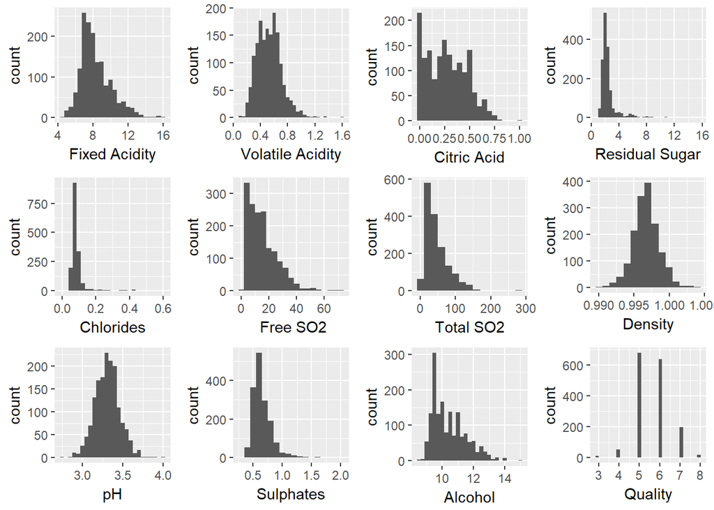

# Univariate Analysis

After creating the univariate graphs of the variables, some observations can be made about the distributions:

- Normal: Density, pH
- Positively Skewed and long-tailed: Fixed Acidity, Citric Acid, Free Sulfur Dioxide, Total Sulfur Dioxide, Sulphates
- Contain Many Outliers: Residual Sugar, Chlorides

Two common transformations for skewed graphs are *log10()* and *sqrt*. We will start by investigating the log10() transformation of the positively skewed graphs.

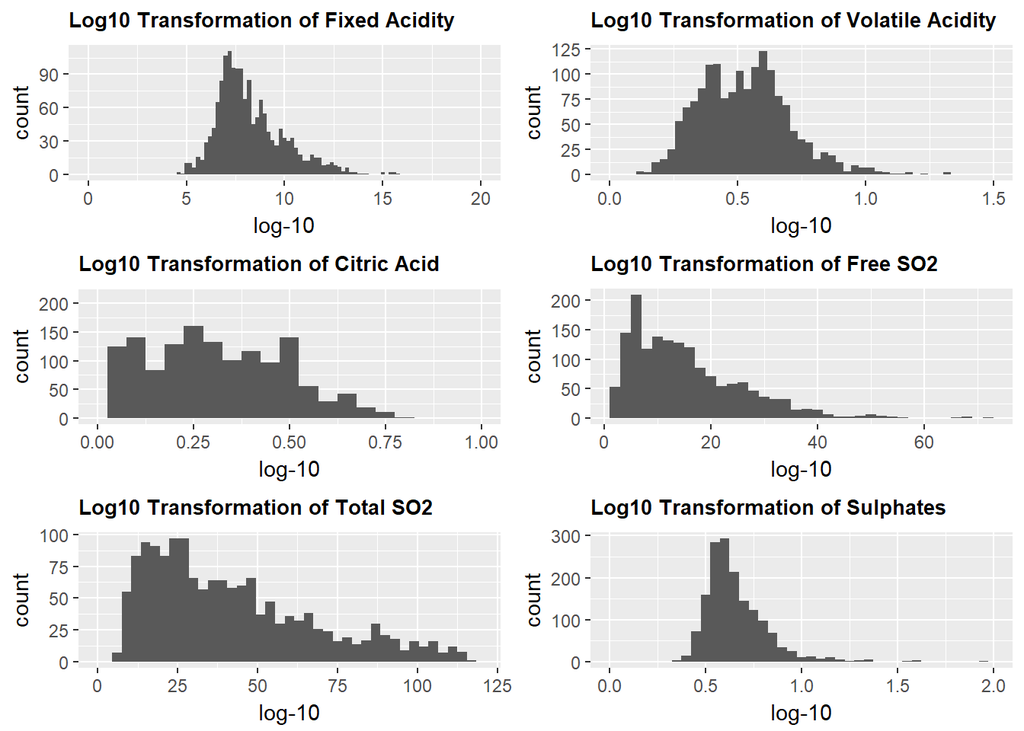

Surprisingly, the log10 transformation did not make any of the graphs normal, although the Volatile Acidity graph does appear to be bimodal. The remaining graphs are positively skewed. Perhaps the square root transformation will be more effective.

Below are the square root transformations of the skewed graphs.

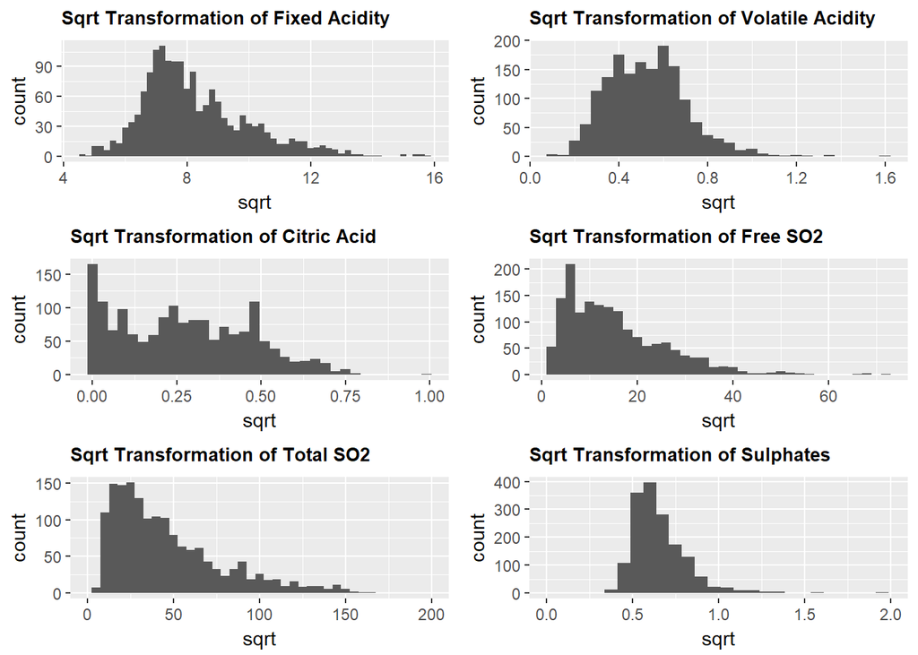

The square root transformation makes the volatile acidity graph normal. The remaining graphs are positively skewed and long-tailed.

After observing the citric acid graphs, it becomes evident that there are several citric acid values of 0.00.

```r
length(subset(prw, citric.acid == 0)$citric.acid)
```

```
## [1] 132
```

We can see that citric acid has 132 values of 0. Important to take this into consideration for future analysis as these values will skew the data.

As previously discussed, the residual sugar and chlorides variables appear to have many outliers. One way to combat this is to limit the values to the 95th percentile. Below are the graphs for 95th percentile of residual sugar and chlorides as well as the log10() and sqrt transformations of those graphs.

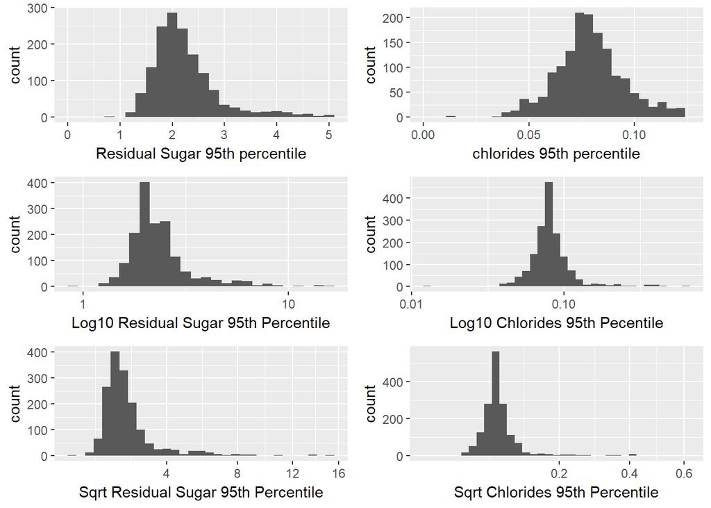

In the next section, I will examine how the different variables influence the wine quality and rating.

# Bivariate Plots Section

We will start our bivariate exploration by creating a scatterplot matrix. A scatterplot matrix will allow us to see the relationships between the different variables.

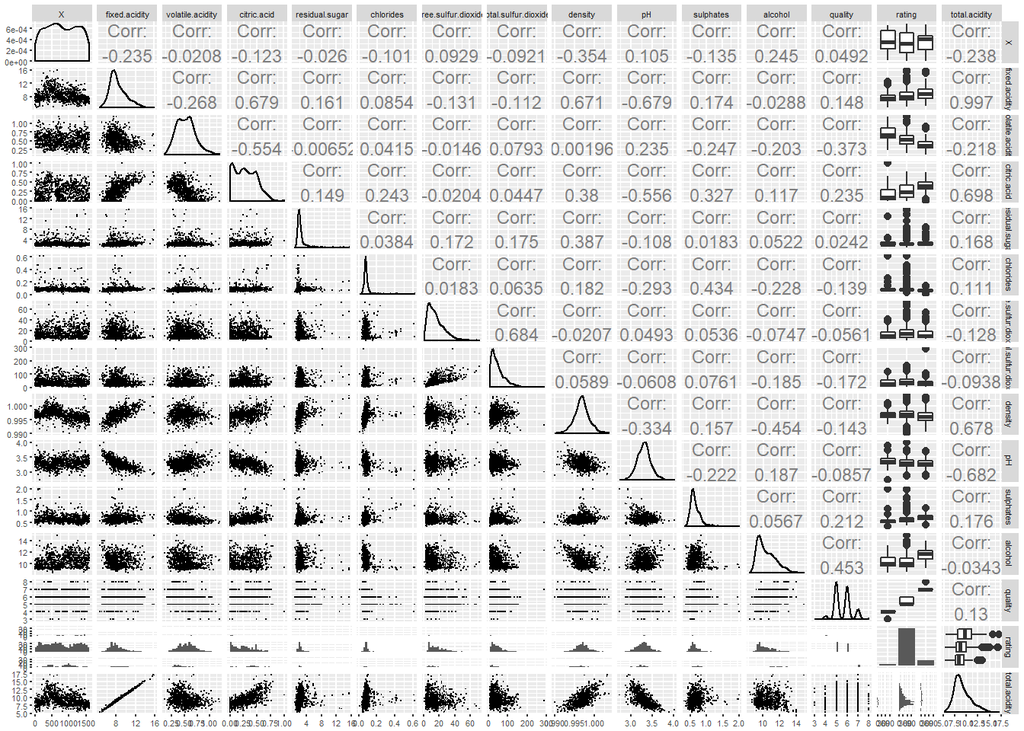

The scatterplot matrix provides the various correlation coefficients for the different variables as well as several different graphs. It appears that the best way to visualize the relationships between the chemical properties of wines versus the quality and rating variables is by creating boxplots.

Although the scatterplot matrix provides a general idea about the relationships between different variables, it is important to quantify these associations. One method for calculating this is using “Pearson’s R” correlation coefficient. The coefficient ranges from -1 to +1 and can be interpreted as the following:

- (+/-) 1: perfect linear relationship
- (+/-) 0.70-0.99: strong correlatory relationship
- (+/-) 0.50-0.69: moderate correlatory relationship
- (+/-) 0.30-0.49: weak correlatory relationship

We will visualize the Pearson’s R between the different statistics by creating a correlation matrix.

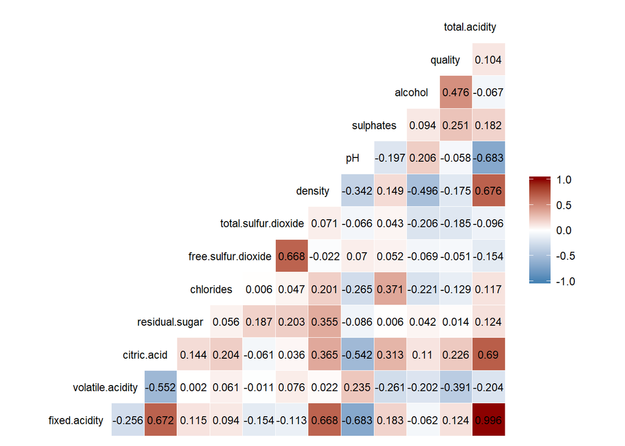

Now, it’s time to visualize the data. Below are the boxplots of the chemical properties found in the dataset versus the quality and rating variables, respectively.The mean value for each boxplot is colored red.

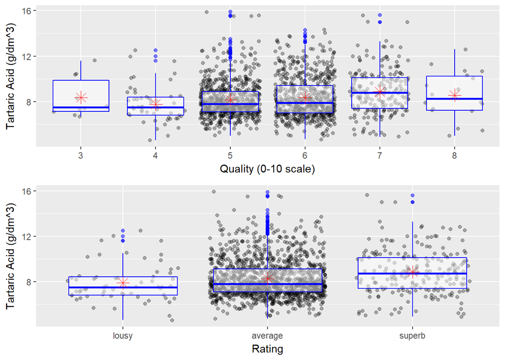

Tartaric Acid acid and wine quality have a Pearson’s R correlation of 0.124, which is a weak positive relationship. The distribution of wine quality appears to fall from 3 to 4, before rising as expected. The majority of the points fall within the average range, with a wine quality of 5 or 6. Not surprisingly, there are several outliers for wines with a quality of 5 or 6. The mean value for the superb wines appears equal to the median, whereas the average and lousy wines have means slightly above the median values.

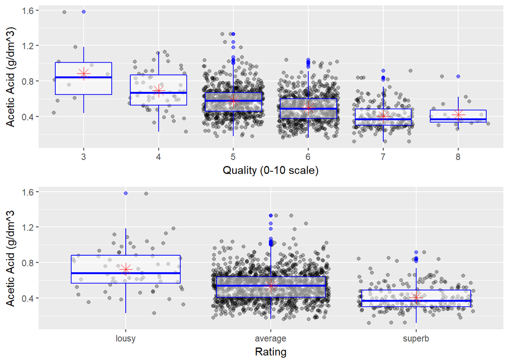

Acetic Acid and wine quality have a Pearson’s R correlation of -0.391, which is a weak negative correlation. The distribution indicates that as wine quality increases, acetic acid drops. The majority of the wines have an average rating, with a wine quality of 5 or 6. The average rated wines have a mean value equal to the median, whereas lousy and superb wines have mean values slightly above the median.

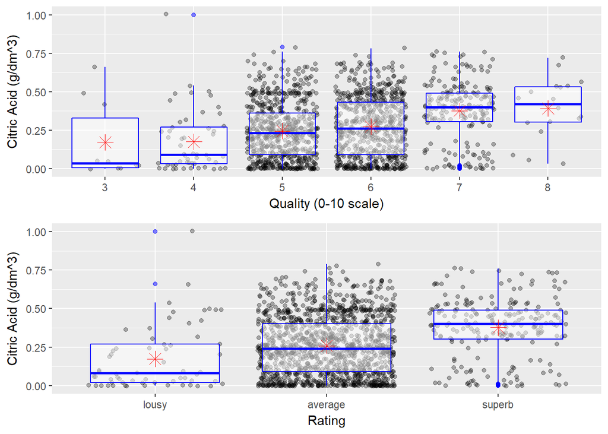

Citric acid and wine quality have a Pearson’s R correlation of 0.226, which is a weak positive correlation. The distribution indicates that as wine quality increases, so does the amount of citric acid. The majority of wines are average with a wine rating of 5 or 6. The lousy wines have a mean value significantly above the median value due to several outliers. The average wines have a mean value slightly above the median and the superb values have a mean value slightly below the mean.

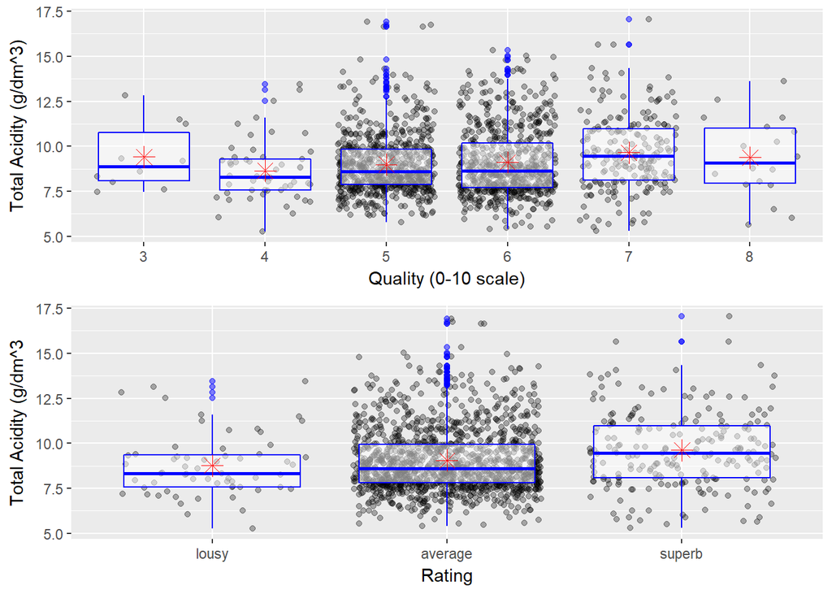

Total Acidity and wine quality have a Pearson’s R correlation of 0.104 which is a weak positive correlation. The total acidity drops from a wine quality of 3 to 4, before rising the remainder of the way. The majority of wines have an average rating with wine quality of 5 or 6. The mean value for superb wines appears equal to the median value whereas the means for lousy and average wines are above the respective median values.

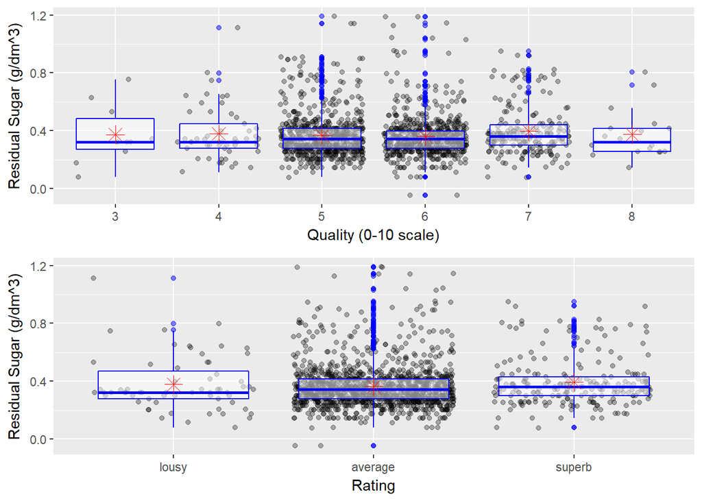

Residual Sugar and wine quality have a Pearson’s R correlation of 0.014, which is an extremely weak correlation. The distribution does not give any clear indication about the relationship between the values. This is not surprising considering the small correlation. The majority of wines are average rated with a quality of 5 and 6. The mean and median value for average and superb wines appear slightly above the medians values for those wines. Lousy wines have a mean value significantly higher than the median value.

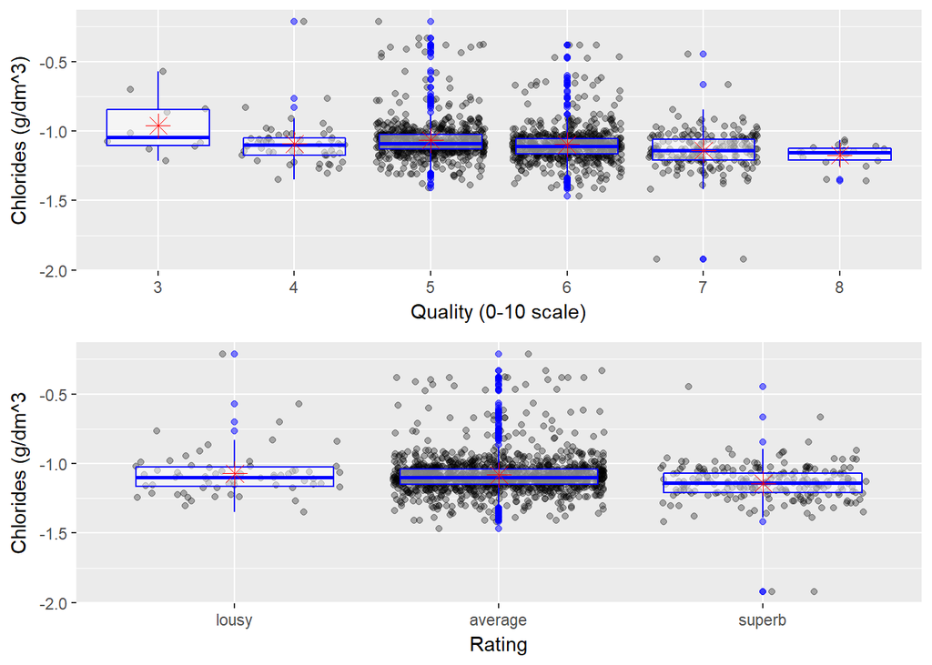

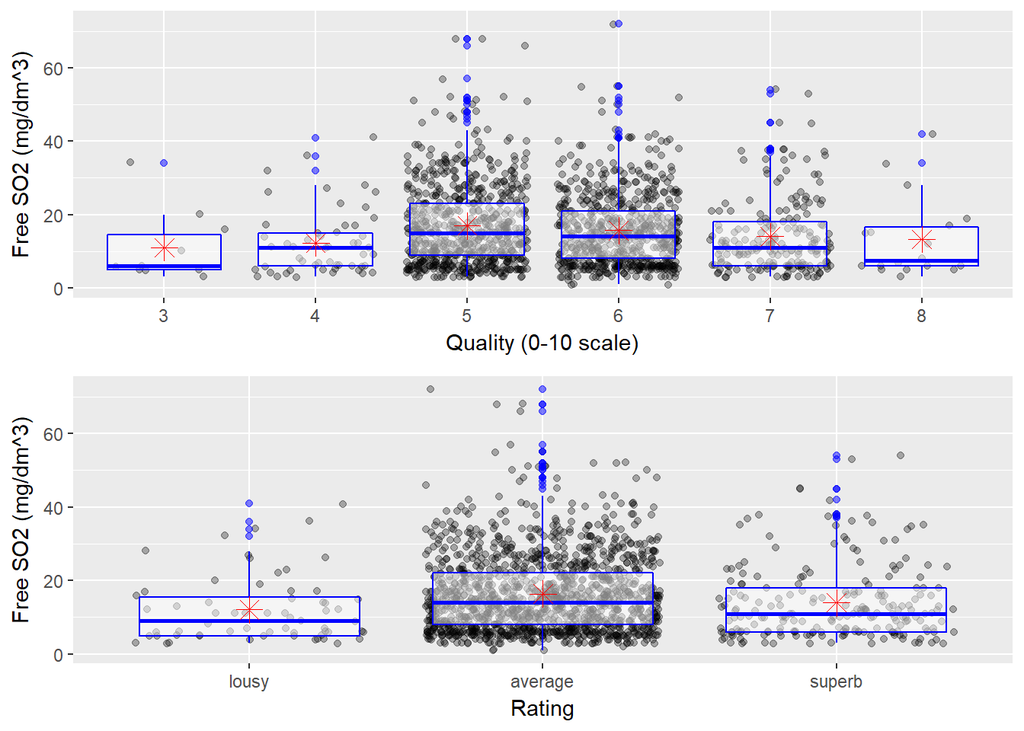

Free Sulfur Dioxide and wine quality have a Pearson’s R correlation of -0.051, which is an extremely weak negative correlation. The amount of free sulfur dioxide increases from wine quality 3-5 before dropping the remainder of the way. This could not have been determined from the Pearson’s R alone, but gives an idea about why the correlation coefficient is so small. The majority of wines have an average rating with a wine quality of 5 or 6. The mean values for all the differently rated wines are above median values (for the same rating). This is due to the presence of many outliers.

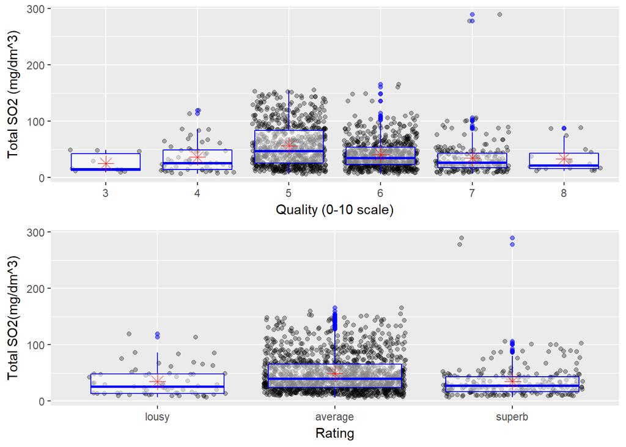

Total Sulfur Dioxide and wine quality have a Pearson’s R correlation of -0.185, a weak negative correlation. The distribution oscillates from low total sulfur dioxides values for lower quality wines, rising for average (3-5 ) wines, before dropping again for higher quality wines (>=6). It is important to note the distribution because it indicates that the correlation value may be misleading.  
The majority of wines have an average rating with a wine quality of 5 or 6. The mean values of the lousy, average, and superb wines appears slightly above the median values for the same rating.

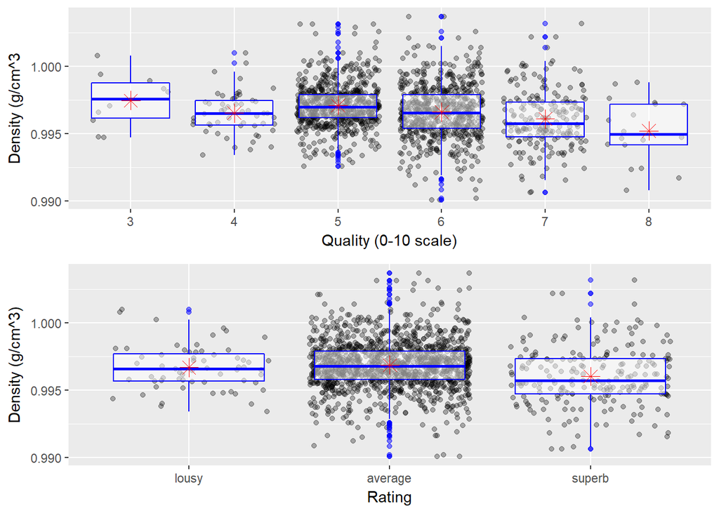

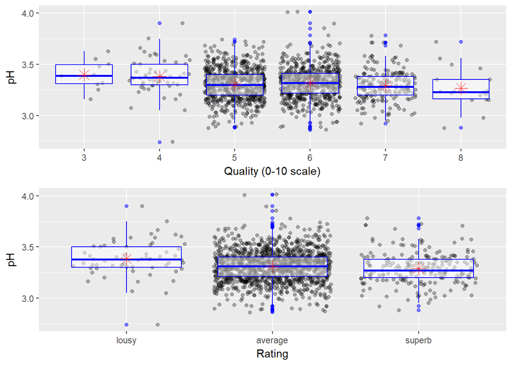

pH and wine quality have a Pearson’s R correlation of -0.058, an extremely weak negative correlation. The distribution is surprisingly more negatively sloped than expected considering the extremely weak negative correlation. However, wine qualities of 3 and 4, and 5 and 6, have the same pH values, respectively. The mean and median values for each of the wine ratings appear the same.

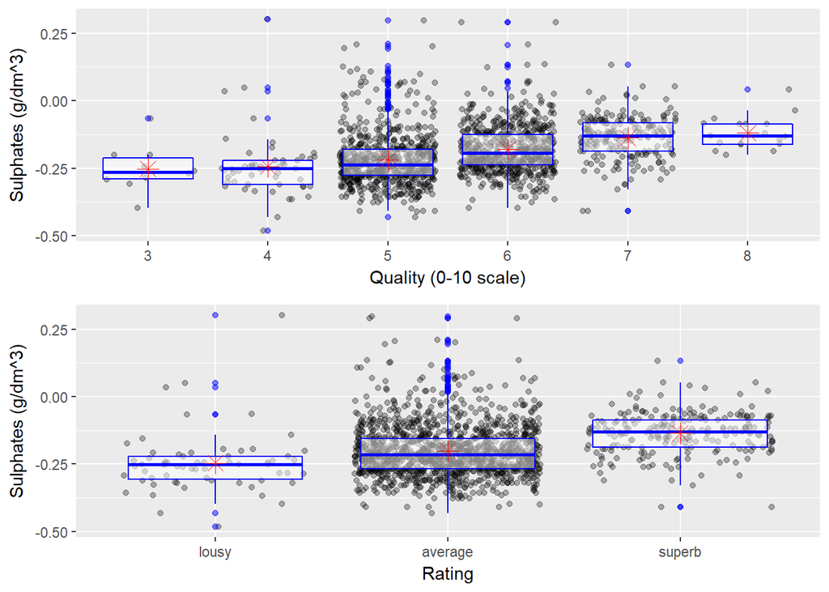

Sulphates and wine quality have a Pearson’s R correlation of 0.251, which is a weak positive correlation. The distribution supports this showing that as wine quality increases, so does the amount of sulphates present. The mean and median values for all the different rated wines appear the same.

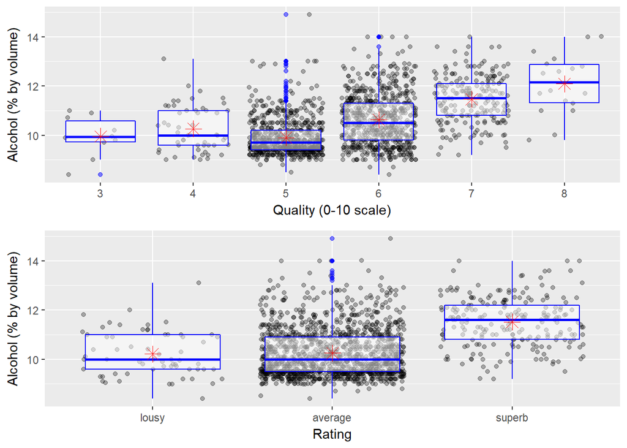

In addition to the relationship between the individual variables and the quality and rating variables, I am also interested in investigating the relationships between different variables. Below are some of the interesting relationships observed from the correlation matrix that will be further explored:

- Fixed acidity and pH have a moderate negative correlation of -0.683
- Density and alcohol have a moderate negative correlation of -0.496
- Free sulfur dioxide and total sulfur dioxide have a positive correlation of 0.668

Below are the scatterplots of the variables.

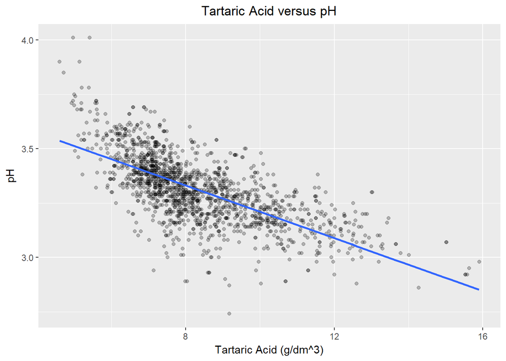

The graph represents the negative correlatory relationship between tartaric acid and pH. The linear regression line is negatively sloped as expected, with the majority of values falling between a pH of 3.0-3.75.

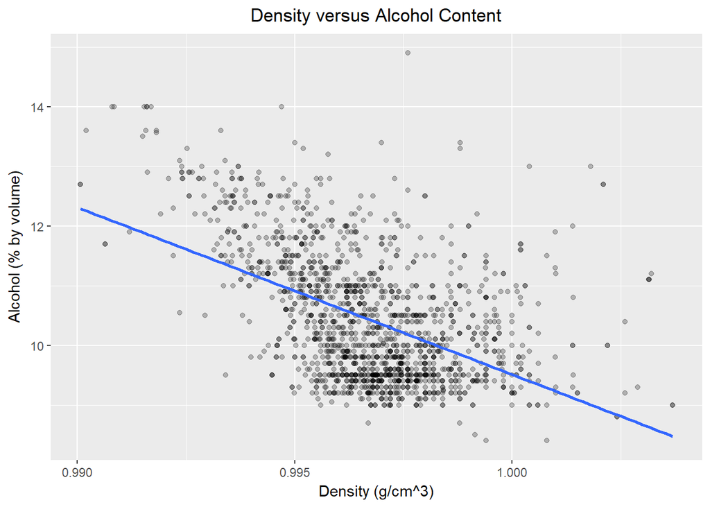

The graph above represents the relationship between alcohol percentage and wine density. The regression line is negatively sloped as expected with the majority of wine falling between a density of 0.995-1.000 g/cm^3.

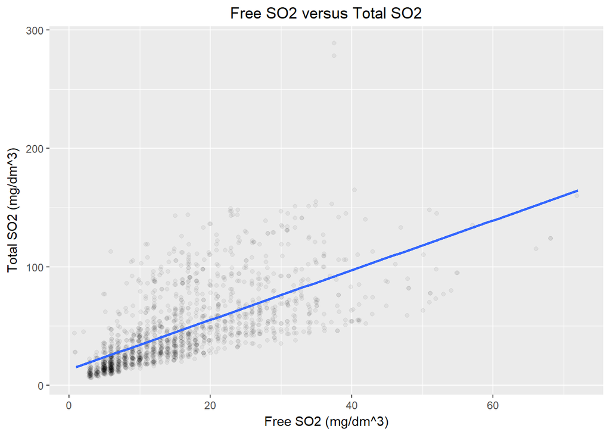

The graph of Free versus Total Sulfur Dioxide indicates that as free sulfur dioxide increases, so does total sulfur dioxide. This intuitively makes sense and also is consistent with the positive correlation factor of 0.668.

# Multivariate Plots and Analysis

After completing univariate and bivariate exploration, I now want to examine the data using multivariate plots.

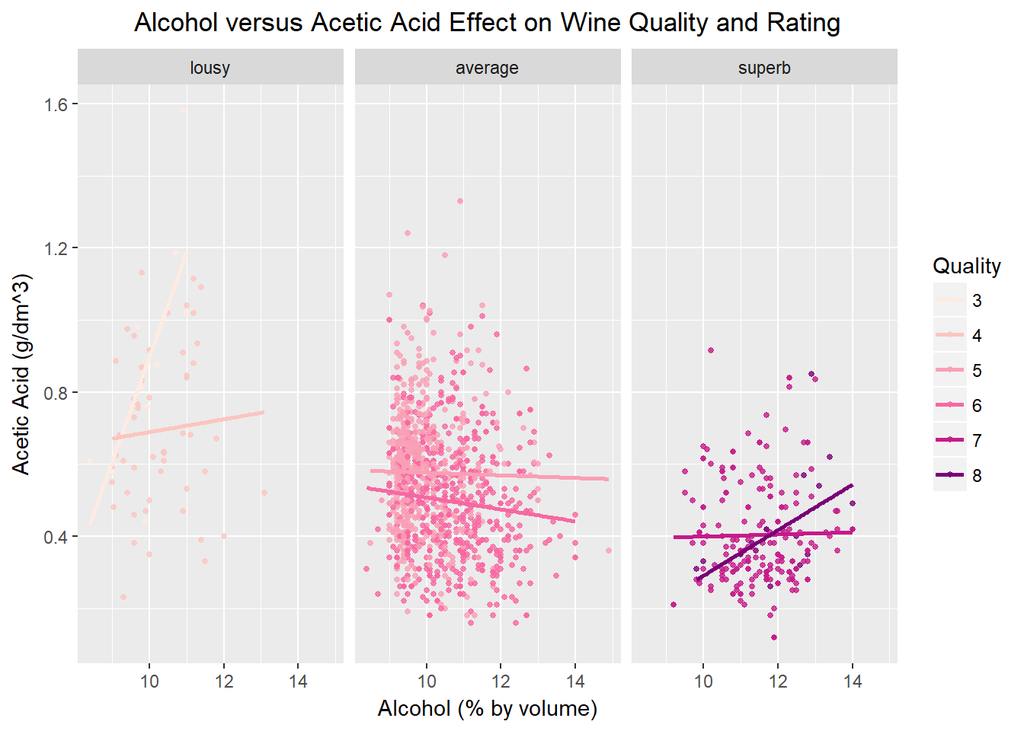

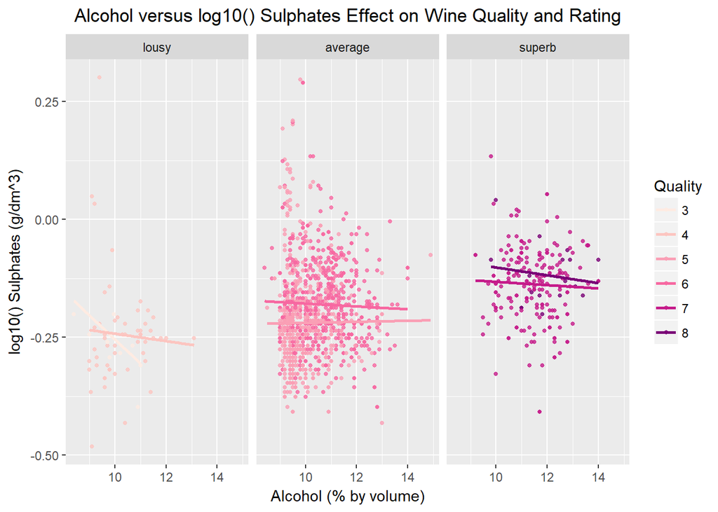

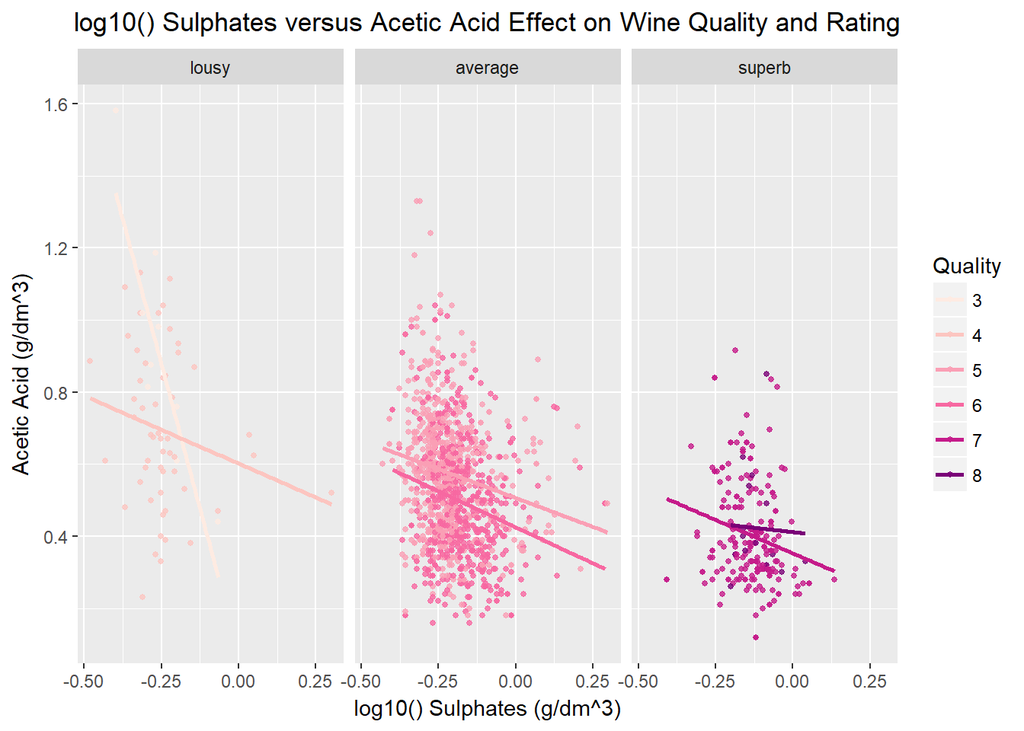

The graph above shows the effect that acetic acid and log10() sulphates have on wine quality and rating. Acetic acid and log10() sulphates appear to be negatively correlated for all wine qualities and ratings. Overall, better rated and higher quality wines have less acetic acid, but greater sulphate content.

# Final Plots and Summary

### Plot One: Acid Boxplots

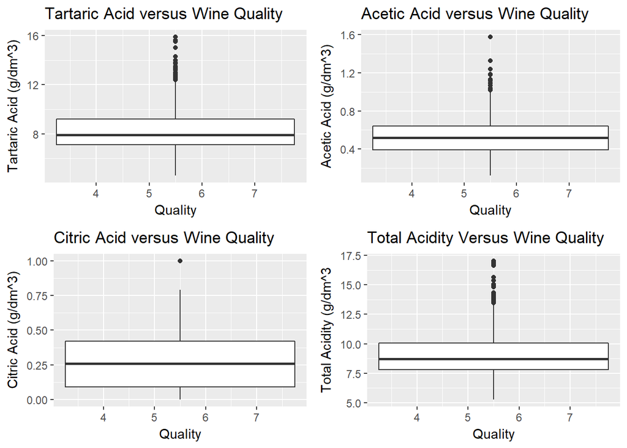

### Plot Two: Density versus Alcohol Plot

[figure not shown]

### Description Two

The graph above plots alcohol, by percent of volume, to density, in grams per centimeters cubed. I was interested in looking at this data in more detail after initially observing that alcohol content and density would be related. Using “geom_smooth()” to observe the conditional means, we can see that as alcohol content increases, the density decreases. This is not a surprise because we earlier noted a -0.496 correlatory relationship between the two factors.

### Plot Three: Alcohol versus Acetic Acid Effect on Wine Quality and Rating

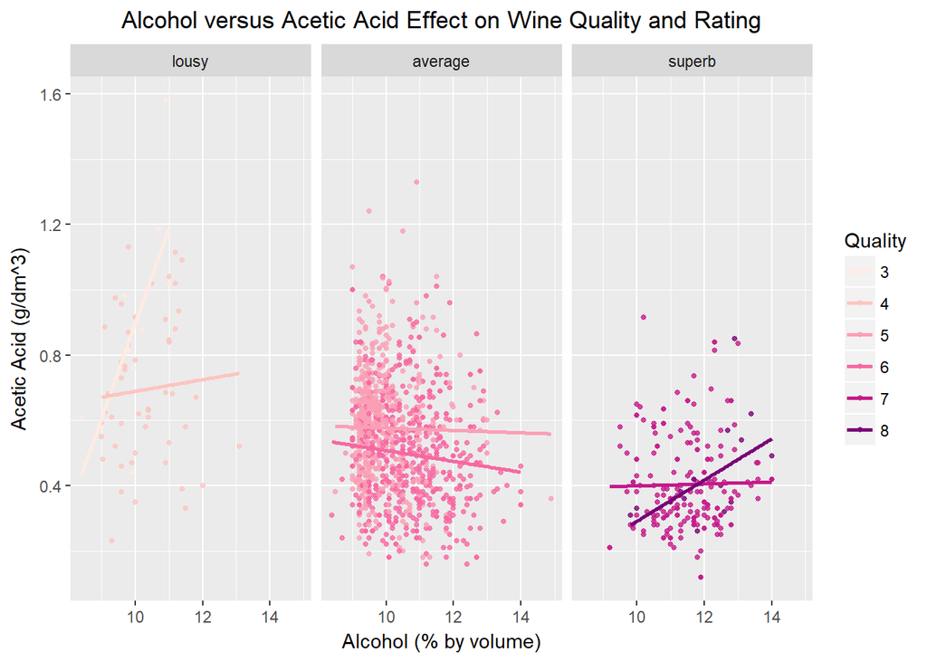

### Description Three

The graph above displays the effects of the two variables most highly correlated with wine quality and rating: acetic acid (volatile acidity) and alcohol content. The quality of wine is represented by the color of the dots and the lines, which are explained by the legend to the right of the graph. Each of the three boxes represents a specific wine rating, ranging from lousy (leftmost) to superb (rightmost). The alcohol content is displayed by by percent volume on the x-axis whereas acetic acid is represented by grams per cubic decimeter on the y-axis.

# Reflection

Exploring the red wine dataset led to many interesting insights. It was observed that the three factors that primarily impact wine quality are alcohol content, volatile acidity (acetic acid), and sulphate content. Alcohol percentage and sulphate content positively correlate with wine quality and rating, whereas acetic acid has a negative correlation. The correlation coefficient for these three values are 0.476, 0.251, and -0.391, respectively. Apart from the effects of the factors on wine quality, alcohol also has -0.496 Pearson’s correlation coefficient with density.

Although the majority of the analysis was straightforward, some difficulties did arise. One cause of these difficulties was being prompted to adjust the graphs’ binwidths. These changes would alter the graph distributions. For example, the initial log10() transformation made the Total Sulfur Dioxide, Sulphates, Fixed and Volatile Acidity univariate graphs normally distributed. However, after altering the binwidth, none of the graphs appeared normal. This happened for other transformations and graphs as well. Determining an appropriate binwidth while remaining unbiased proved difficult. Another problem encountered was using the square root and log transformations for the univariate graphs prevented me from adjusting the x-axis labels. Finally, I had several issues creating the scatterplot matrix such as making sure the graphs and correlation coefficients were legible.

There are some improvements that can be made to improve future analysis of the dataset. One suggestion is to increase the amount of the data collected for “lousy” and “superb” rated wine. It is evident from graphs, such as final plot 3, that the majority of the data points fall in the average range. Adding more data points would improve the quality of the analysis.